# Judgement ⑥ — coreference: does the model use upstream context?

The weakest judgement to validate — the frozen run had zero coreference items (a parent-id defect), so we probe it directly by **context ablation**: classify each (comment, drug) with its parent context and without. A model that resolves coreference should change its answer when the context is removed on **context-necessary** items (the drug is *only* in the parent), and *not* on **control** items (the drug is already in the comment, so the context is redundant — the noise floor). The gap between the two is the coreference signal.

*(loaded — 4514 classifications, 22 models; 16 context-necessary pairs)*

## 1. Does removing context change the answer — necessary vs control?

Per model: how often the sentiment/signal flips when the parent context is ablated, on context-necessary items vs control items.

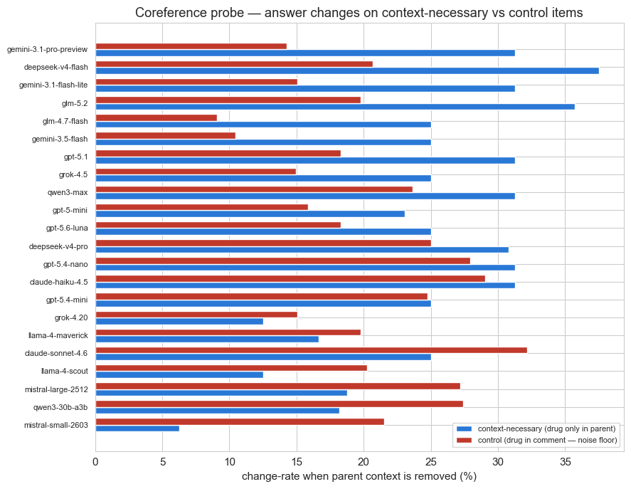

**Context-necessary items change 25% of the time when the parent is removed, vs 20% for control items** — a **+5%** gap in the expected direction, but a *weak* one. Two reasons to read it cautiously: the control change-rate is **20%** — removing *redundant* context shouldn't move the answer at all, so the models are noticeably unstable to prompt edits, and the coreference signal sits only ~5 points above that noise floor. And the context-necessary group is tiny (**16 pairs**), so the gap is suggestive, not conclusive. **Best read: a hint that models use the reply chain, not proof — ⑥ stays the least-validated judgement.**

## 2. Which models depend on context most

Models with a **large necessary-minus-control gap** resolve coreference strongly (they lean on the parent when the drug isn't local). A **small gap** means either the model ignores upstream context (a coreference weakness) or it guesses locally regardless. A model whose *control* change-rate is high is unstable — its answer wobbles even when context is redundant, which is noise, not coreference. Read the two bars together: the healthy pattern is a tall blue bar and a short red one.

| model | necessary Δ-rate | control Δ-rate | gap (coreference signal) |
| --- | --- | --- | --- |
| gemini-3.1-pro-preview | 31% | 14% | +17% |
| deepseek-v4-flash | 38% | 21% | +17% |
| gemini-3.1-flash-lite | 31% | 15% | +16% |
| glm-5.2 | 36% | 20% | +16% |
| glm-4.7-flash | 25% | 9% | +16% |
| gemini-3.5-flash | 25% | 10% | +15% |
| gpt-5.1 | 31% | 18% | +13% |
| grok-4.5 | 25% | 15% | +10% |
| qwen3-max | 31% | 24% | +8% |
| gpt-5-mini | 23% | 16% | +7% |
| gpt-5.6-luna | 25% | 18% | +7% |
| deepseek-v4-pro | 31% | 25% | +6% |
| gpt-5.4-nano | 31% | 28% | +3% |
| claude-haiku-4.5 | 31% | 29% | +2% |
| gpt-5.4-mini | 25% | 25% | +0% |
| grok-4.20 | 12% | 15% | -3% |
| llama-4-maverick | 17% | 20% | -3% |
| claude-sonnet-4.6 | 25% | 32% | -7% |
| llama-4-scout | 12% | 20% | -8% |
| mistral-large-2512 | 19% | 27% | -8% |
| qwen3-30b-a3b | 18% | 27% | -9% |
| mistral-small-2603 | 6% | 22% | -15% |

## 3. Verdict

- **Weak-positive, not a clean pass.** The gap is in the right direction (**25%** necessary vs **20%** control, **+5%**), so models *lean* on the reply chain — but the effect is small and rides on only 16 context-necessary pairs. ⑥ remains the least-validated of the eleven.

- **The 20% control change-rate is a red flag of its own** — removing redundant context shouldn't change the answer, so the classifier is fairly unstable to prompt edits (temperature is pinned to 0, so this is prompt-sensitivity, not sampling). That instability, not coreference, may be the bigger reliability story.

- **We could only ever show *use*, not *correctness*** — ablation shows the model depends on context, never that it resolves it right. With no coreference gold and a defect-zeroed frozen run, this probe on real items is the honest ceiling for ⑥.

- **Recommendation:** widen the context-necessary set (construct thread-structure items) and drive down the control change-rate (prompt-stability check) before treating coreference as validated.

## Limitations

- **Change ≠ correctness** — ablation shows the model *depends on* context, not that its resolution is right. With no coreference gold, "uses context" is the strongest claim available (the plan's stated ceiling for ⑥).
- **Context-necessary is inferred** from whether the drug string appears in the comment text — a surface heuristic; a drug referred to only by pronoun/synonym in the comment could be mislabelled.
- **Depends on the parent_context field** in the IRR frame (280/300 pairs) at depth 2; deeper chains untested.
- Measures whether a resolution step fires, not any treatment effect. Not medical advice.

**Provenance**

| item | value |
| --- | --- |
| method | context ablation — classify with vs without parent context; change-rate vs noise floor |
| models | 22 |
| pairs | 109 |
| context-necessary | 16 |
| metric | change-rate under context ablation (necessary vs control) |
| skill | research-assistant v2 |

Measures whether a resolution step fires, not treatment effects. Not medical advice.